# Assignment-3

Ojaas Hampiholi

2/3/2020

# Loading Libraries:

```r
library(tidyverse)
library(NHANES)
```

```r
library(ggplot2)
library(gridExtra)
library(MASS)
library(dplyr)
```

# Subsection 1:

## The relation between Age and Average Systolic BP:

Since the data set is very large(10000 rows), I have taken mean of values of BP readings for common values of Age, Height and Weights depending on the comparisions to be made.

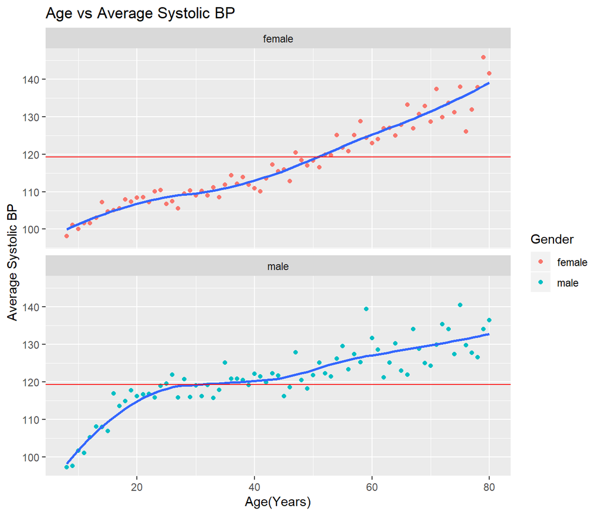

```r
#View(NHANES)
workingData = subset(NHANES, select = c("BPSysAve", "Age", "Weight", "Height", "Gender"))
#View(workingData)

ageData = workingData %>% group_by(Gender, Age) %>% summarise(meanBP = mean(BPSysAve, na.rm = TRUE))
#View(ageData)
ageData = na.omit(ageData)

ggplot(ageData, aes(x= Age, y= meanBP)) + geom_point(aes(color = Gender)) +
    geom_smooth(se = FALSE, span = 0.6) +
    geom_hline(yintercept = mean(ageData$meanBP), color = "red") +
    ggtitle("Age vs Average Systolic BP") +

    xlab("Age(Years)") + ylab("Average Systolic BP") +
    facet_wrap(~ Gender, nrow = 2) +
    xlim(8,80)
```

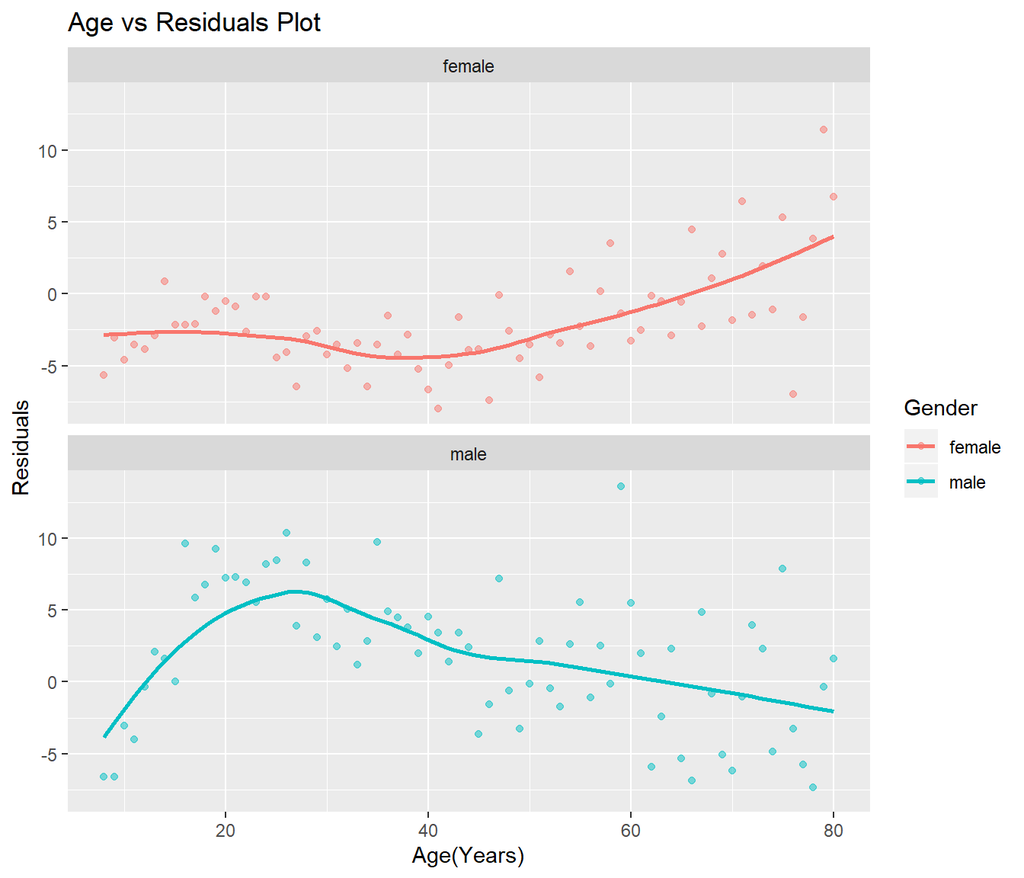

```r
age = lm(meanBP ~ Age, data = ageData)
ageResiduals = data.frame(Age = ageData$Age, Gender = ageData$Gender, residual = residuals(age))
ggplot(ageResiduals, aes(x= Age, y= residual, color= Gender)) + geom_point(alpha = 0.5) +
  facet_wrap(~Gender,nrow = 2) + geom_smooth(se = FALSE) + xlab("Age(Years)") + ylab("Residuals")+
  ggtitle("Age vs Residuals Plot")
```

# Subsection 2:

## The relation between Height and Average Systolic BP:

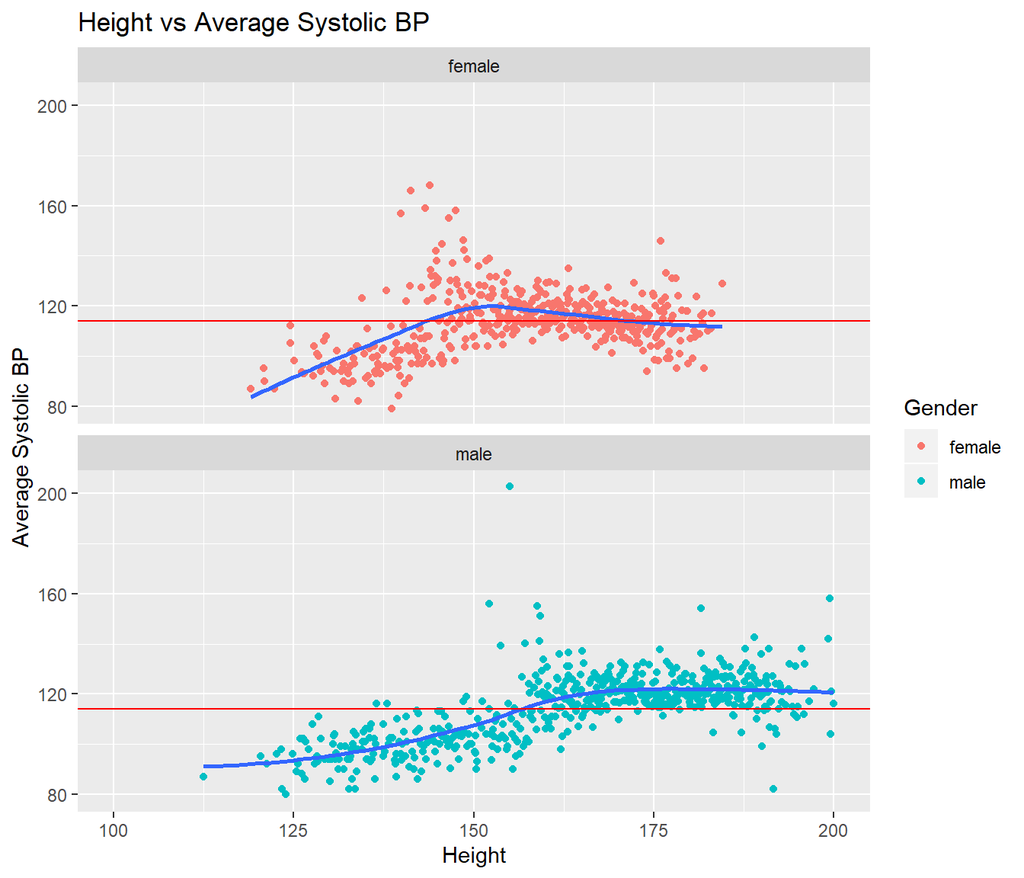

```r
heightData = workingData %>%
            group_by(Gender, Height) %>%
              summarise(meanBP = mean(BPSysAve, na.rm = TRUE))
#View(ageData)
heightData = na.omit(heightData)

ggplot(heightData, aes(x= Height, y= meanBP)) + geom_point(aes(color = Gender)) +
    geom_smooth(se = FALSE) +
    geom_hline(yintercept = mean(heightData$meanBP), color = "red") +
    ggtitle("Height vs Average Systolic BP") +
    xlab("Height") + ylab("Average Systolic BP") +
    facet_wrap(~ Gender, nrow = 2) +
    xlim(100,200)
```

A loess model can be fitted to the trend data for the relationship between Height and BP for both men and women. But, the graph for data shows outliers for both men and women for the comparision.The outliers for data provided for women are less extreme as compared to outliers for men.

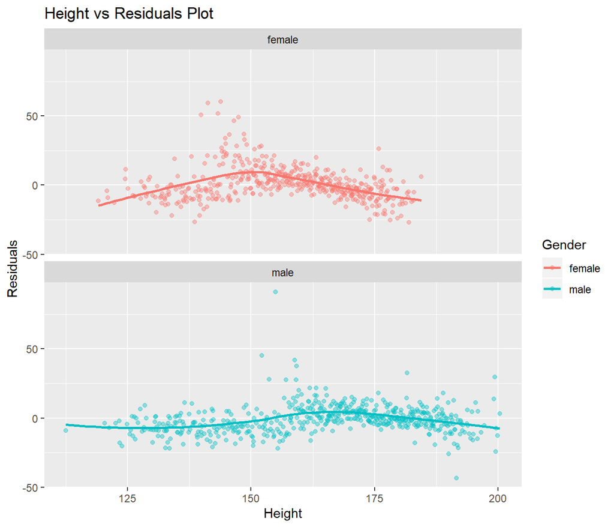

```r
height = lm(meanBP ~ Height, data = heightData)
heightResiduals = data.frame(Height = heightData$Height, Gender = heightData$Gender, residual = residuals(height))
ggplot(heightResiduals, aes(x= Height, y= residual, color= Gender)) + geom_point(alpha = 0.4) +
  facet_wrap(~Gender,nrow = 2) + geom_smooth(se = FALSE) + xlab("Height") + ylab("Residuals")+
  ggtitle("Height vs Residuals Plot")
```

The data can be fit perfectly using a loess model. Applying log and square root transformation did not help the graph much. The spread of outliers across the data for women is less severe as compared to men.

# Subsection 3:

## The relation between Weight and Average Systolic BP:

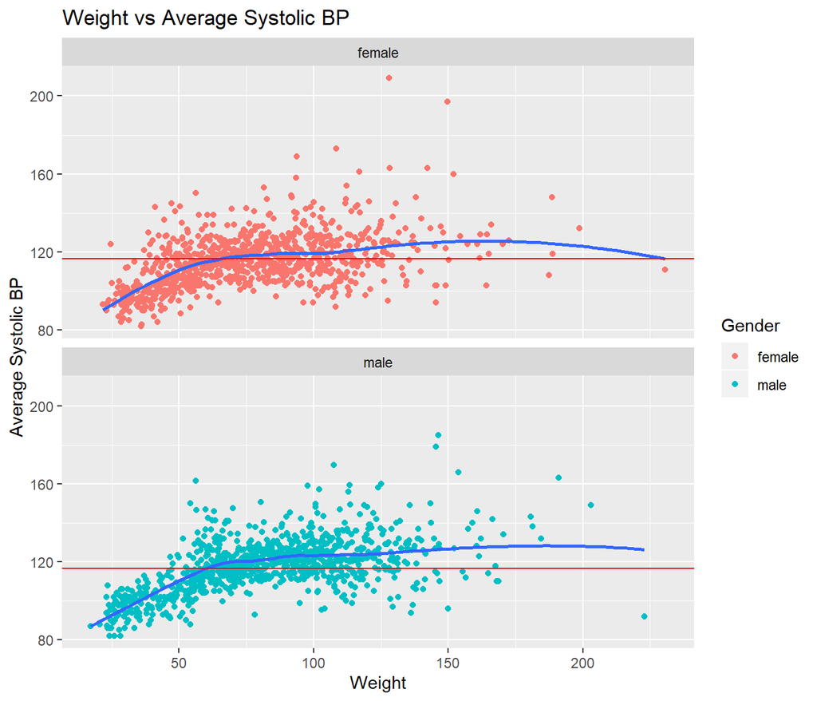

```r
weightData = workingData %>%
            group_by(Gender, Weight) %>%
              summarise(meanBP = mean(BPSysAve, na.rm = TRUE))
#View(ageData)
weightData = na.omit(weightData)

ggplot(weightData, aes(x= Weight, y= meanBP)) + geom_point(aes(color = Gender)) +
    geom_smooth(se = FALSE, span = 0.6) +
    geom_hline(yintercept = mean(weightData$meanBP), color = "red") +
    ggtitle("Weight vs Average Systolic BP") +
    xlab("Weight") + ylab("Average Systolic BP") +
    facet_wrap(~ Gender, nrow = 2)
```

The graph above showws relationship between Weight and BP for men and women. In data for women, the outliers are more as compared to the data for men. Hence, a loess model is fitted here, which has a sharp curve at the smaller weights in both the genders, but the graph continues to have a curve even at higher weights.

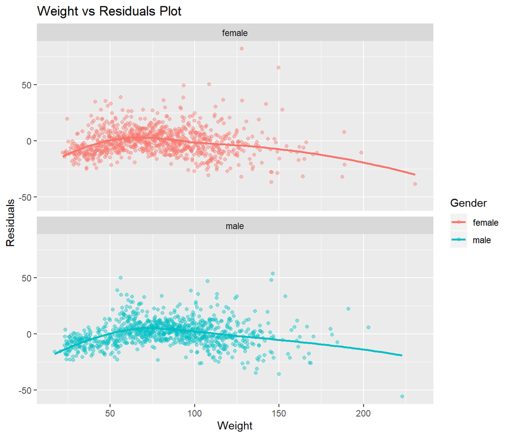

```r
weight = lm(meanBP ~ Weight, data = weightData)
weightResiduals = data.frame(Weight = weightData$Weight, Gender = weightData$Gender, residual = residuals(weight))
ggplot(weightResiduals, aes(x= Weight, y= residual, color= Gender)) + geom_point(alpha = 0.4) +
  facet_wrap(~Gender,nrow = 2) + geom_smooth(se = FALSE) + xlab("Weight") + ylab("Residuals")+
  ggtitle("Weight vs Residuals Plot")
```

The data cannot be fit perfectly using a loess model. The spread of outliers across the data for women is more severe as compared to men. Hence, linear model cannot be applied to the data without much problems and approximations. The log and square root transforms again provide no better results in this case as well.

# Conclusions:

The graph for Age vs BP perfectly fits a loess model. Also, for Height and Weight the linear model is not the most optimum choice, this can be concluded from the residual graphs plotted above. But, a loess model can be applied in those cases as well, because it won’t lead to a major problem, if and when a formal inference has to be made.